## Question no.6

**(a)** We will use 10-fold cross validation for model selection.

```r
set.seed(1)
library(ISLR)
library(MASS)
library(boot)
attach(Wage)
```

we will consider polynomial up to degree 7. We will create an list to store cross validation errors.

```r
cv.errors = rep(NA,7)
```

```r
for (d in 1:7){
  glm.fit = glm(wage~poly(age,d), data=Wage)
  cv.errors[d] = cv.glm(Wage, glm.fit, K=10)$delta[1]
}
```

First element of delta is raw error and 2nd one is bias corrected version of it.

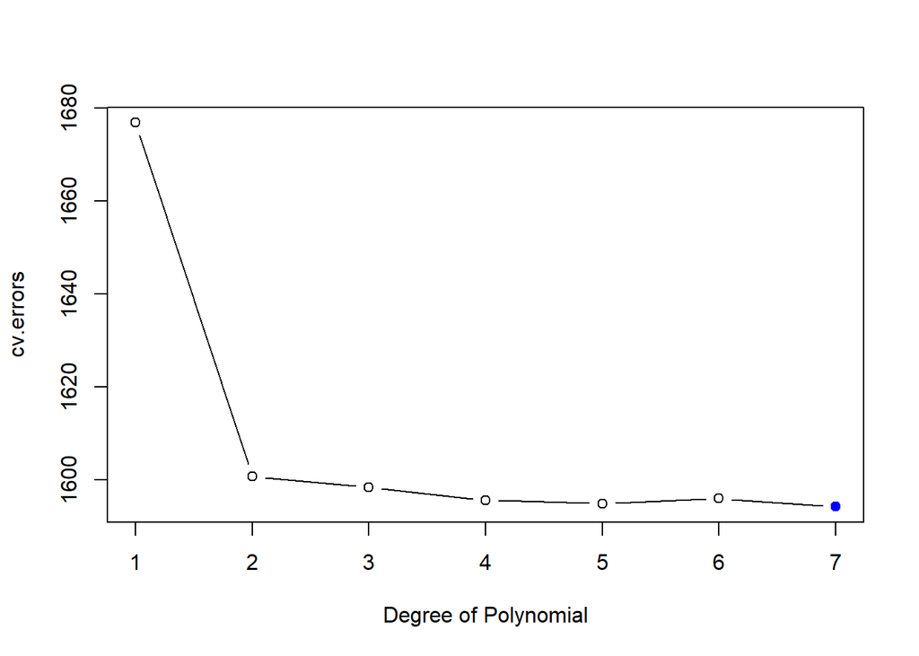

```r
plot(x=1:7, y=cv.errors, type="b", xlab="Degree of Polynomial")
points(which.min(cv.errors),cv.errors[which.min(cv.errors)], col="blue", pch=19)
```

From plot we can see that there is no significant change in error after degree 3. as we have also seen in lab there is no significant p-value after degree 3.

we will now fit polynomial of degree 3 and plot it.

```r
poly.fit3 = lm(wage~poly(age,3), data=Wage)
age.grid = seq(from=range(age)[1], to= range(age)[2])
preds = predict(poly.fit3, newdata=list(age=age.grid), se=TRUE)
se.bands = cbind(preds$fit+2*preds$se.fit, preds$fit+2*preds$se.fit)
```

plotting:

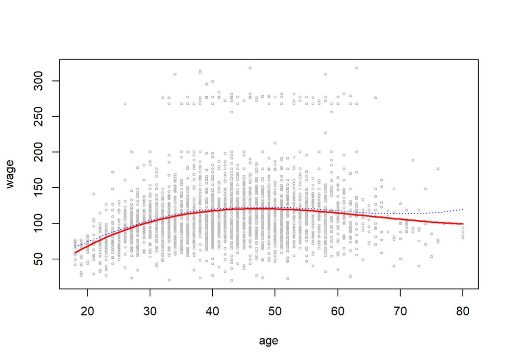

```r
plot(age,wage,xlim=range(age), cex=0.5, col="grey")
lines(age.grid, preds$fit, lwd=2, col="red")
matlines(age.grid, se.bands,lwd=1 ,lty=3, col="blue")
```

**(b)** using cross validation to decide optimum number of cuts

```r
step.error = rep(NA,10)
for(i in 2:10){
  Wage$age.cut = cut(Wage$age,i)
  glm.fit = glm(wage~age.cut, data=Wage)

  step.error[i] = cv.glm(Wage,glm.fit, K=10)$delta[1]

}
```

we will now plot errors excluding first element of step error.

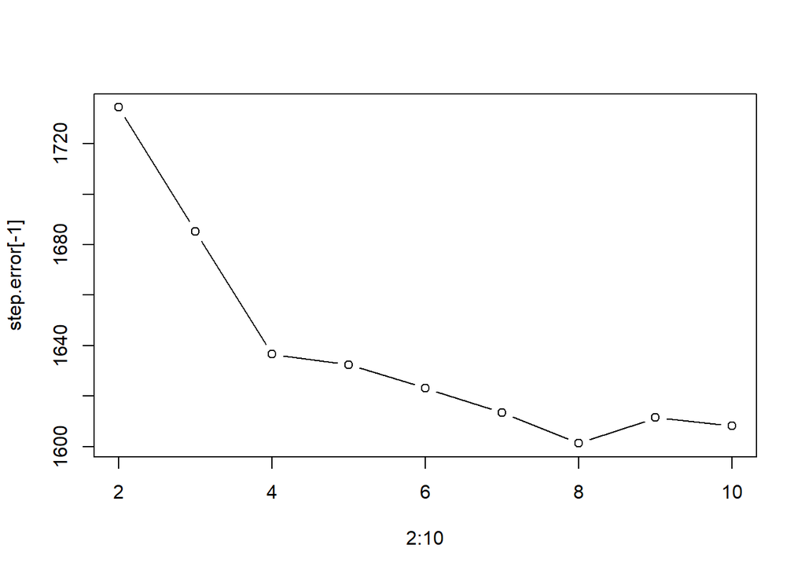

```r
plot(2:10, step.error[-1], type="b")
```

We can see that CV error is minimum for 8 cuts. We will now fit a model with 8 cuts.

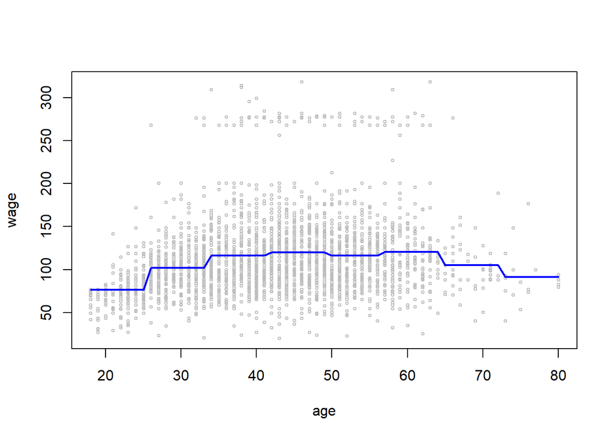

```r
step.fit = glm(wage~cut(age,8), data=Wage)
preds = predict(step.fit, newdata=list(age=age.grid))
plot(wage~age, data=Wage, cex=0.5, col="grey")
lines(age.grid, preds, col="blue", lwd=2)
```

## Question no.7

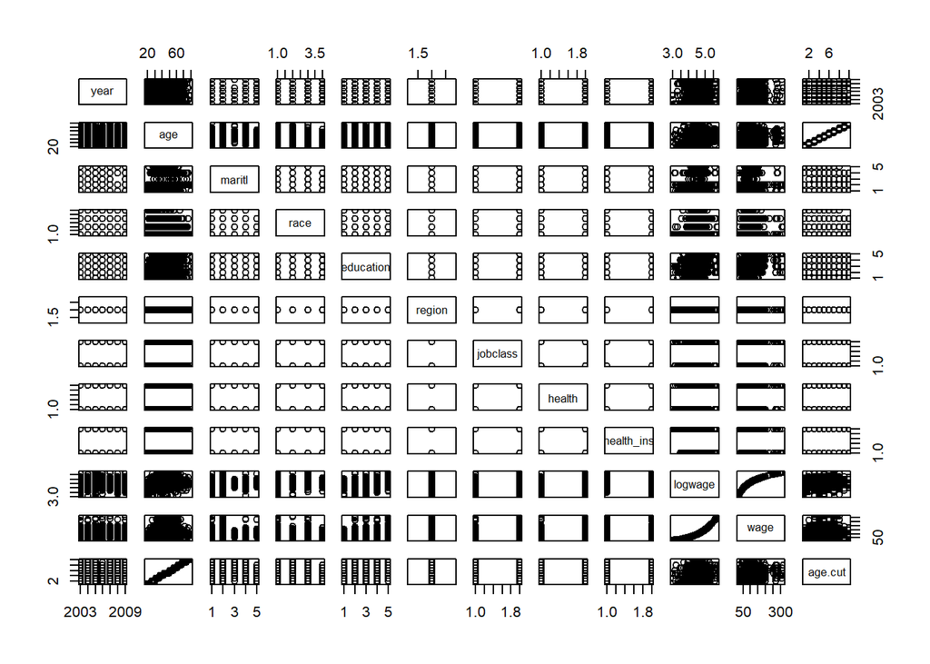

```r
pairs(Wage)
```

```r
summary(Wage$maritl)
```

```
## 1. Never Married       2. Married       3. Widowed      4. Divorced
##              648             2074               19              204
##     5. Separated
##               55
```

```r
summary(Wage$jobclass)
```

```
##  1. Industrial 2. Information
##           1544           1456
```

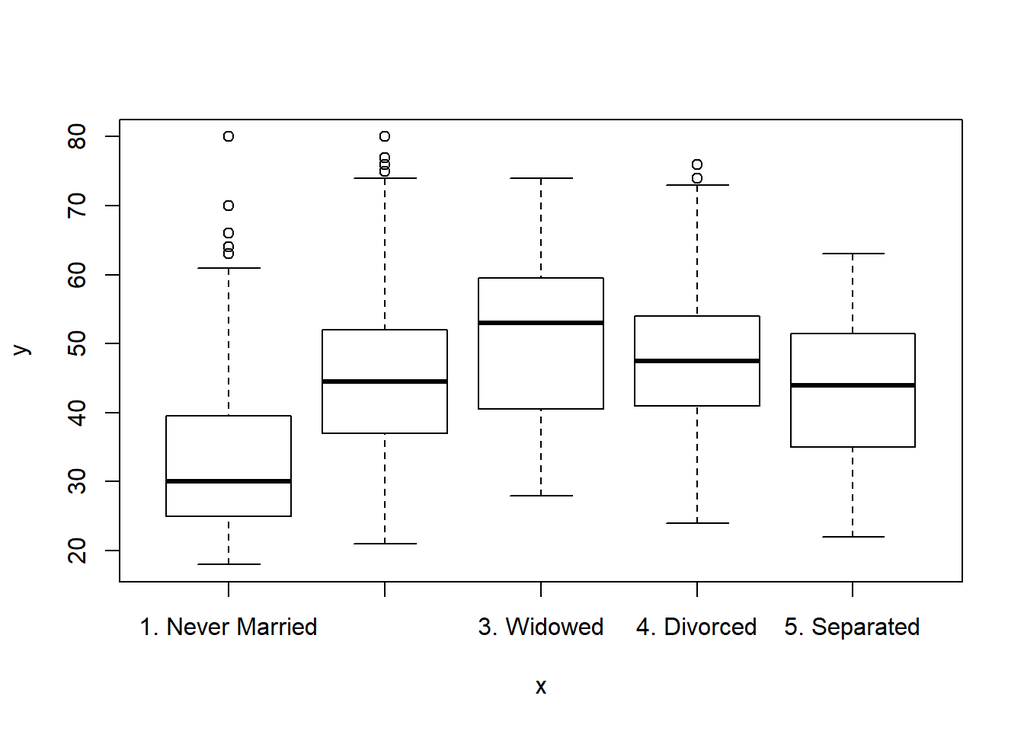

```r
plot(Wage$maritl, Wage$age)
```

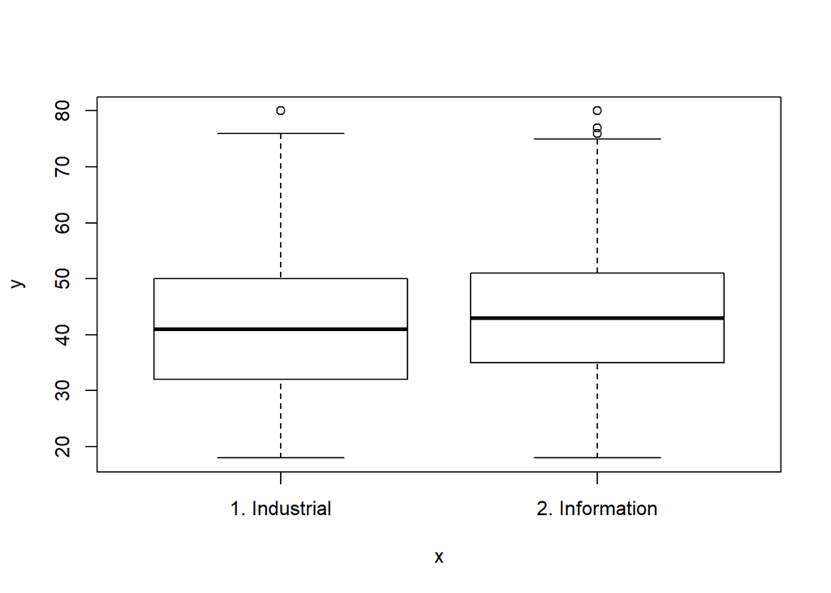

```r
plot(Wage$jobclass, Wage$age)
```

NO particular difference.

**Polynomial and step**

```r
fit1 = lm(wage~maritl, data=Wage)
fit2 = lm(wage~jobclass, data=Wage)
fit3 = lm(wage~maritl + jobclass, data=Wage)
anova(fit1,fit2, fit3)
```

```
## Analysis of Variance Table
##
## Model 1: wage ~ maritl
## Model 2: wage ~ jobclass
## Model 3: wage ~ maritl + jobclass
##   Res.Df     RSS Df Sum of Sq      F    Pr(>F)
## 1   2995 4858941
## 2   2998 4998547 -3   -139606 29.932 < 2.2e-16 ***
## 3   2994 4654752  4    343795 55.283 < 2.2e-16 ***
## ---
## Signif. codes:  0 '***' 0.001 '**' 0.01 '*' 0.05 '.' 0.1 ' ' 1
```

We cannot fit splines on categorical data. **GAMs**

```r
library(gam)
fit4 = gam(wage ~ maritl + jobclass + s(age,4), data= Wage)
anova(fit1, fit2, fit3, fit4)
```

```
## Analysis of Variance Table
##
## Model 1: wage ~ maritl
## Model 2: wage ~ jobclass
## Model 3: wage ~ maritl + jobclass
## Model 4: wage ~ maritl + jobclass + s(age, 4)
##   Res.Df     RSS      Df Sum of Sq      F    Pr(>F)
## 1   2995 4858941
## 2   2998 4998547 -3.0000   -139606 31.082 < 2.2e-16 ***
## 3   2994 4654752  4.0000    343795 57.408 < 2.2e-16 ***
## 4   2990 4476501  4.0002    178252 29.764 < 2.2e-16 ***
## ---
## Signif. codes:  0 '***' 0.001 '**' 0.01 '*' 0.05 '.' 0.1 ' ' 1
```